# Project Overview

## Project

```python
### Architecture Picture
```

[output not shown]

# Setup

### Initialize Spark

```python
# Import the findspark module
import findspark
from pyspark.sql import SparkSession

# Initialize via the full spark path (Linux)
findspark.init("/usr/local/spark/")

spark = (
    SparkSession.builder
    .master("local[*]")  # Specify number of cores
    .appName("SparkProject")  # Set name for application
    .config("spark.executor.memory", "16gb")  # Specify memory
    .getOrCreate()
)

sc = spark.sparkContext

# Verify spark session
print(spark.version)
```

```
3.0.1
```

### Helper functions for library importing

This helper function checks whether a given Python library is installed by attempting to import it. If the import fails due to a missing module (ImportError), it automatically installs the library using pip and confirms the installation.

```python
import importlib
import subprocess
import sys

# Check for library and if not yet installed, install
def check_library(library):
    try:
        importlib.import_module(library)
        print(f"{library} is installed.")
    except ImportError:
        print("Not yet installed. Installing now...")
        subprocess.check_call([sys.executable, "-m", "pip", "install", library])
        print(f"{library} installed.")
```

```python
# Check for needed libraries with helper function
check_library("matplotlib")
check_library("wordcloud")
check_library("Pillow")
```

```
matplotlib is installed.
wordcloud is installed.
Not yet installed. Installing now...
Pillow installed.
```

# Dataset

### Import Dataset

```python
input_file = "./data/Posts_Cleaned_2024.csv"
df_posts = spark.read.csv(input_file, header=True, inferSchema=True, multiLine=True, escape='"', quote='"')
```

```python
df_posts.dtypes
```

```
[('Id', 'int'),
 ('PostTypeId', 'int'),
 ('Score', 'int'),
 ('Title', 'string'),
 ('Body', 'string'),
 ('Tags', 'string'),
 ('ViewCount', 'int'),
 ('AnswerCount', 'int'),
 ('CommentCount', 'int'),
 ('CreationDate', 'timestamp'),
 ('ClosedDate', 'timestamp')]
```

```python
df_posts.show(3)
```

```
+--------+----------+-----+--------------------+--------------------+--------------------+---------+-----------+------------+--------------------+----------+
|      Id|PostTypeId|Score|               Title|                Body|                Tags|ViewCount|AnswerCount|CommentCount|        CreationDate|ClosedDate|
+--------+----------+-----+--------------------+--------------------+--------------------+---------+-----------+------------+--------------------+----------+
|77740724|         1|    0|formkit input dyn...|try use formkit r...|  <nuxt.js><formkit>|       50|          0|           0|2024-01-01 01:06:...|      null|
|77740815|         1|    0|git bash able dis...|href net png rel ...|<node.js><gatsby>...|       16|          0|           0|2024-01-01 02:26:...|      null|
|77740915|         1|    1|flutter app crash...|use code googlesi...|<ios><flutter><fi...|      308|          1|           0|2024-01-01 03:50:...|      null|
+--------+----------+-----+--------------------+--------------------+--------------------+---------+-----------+------------+--------------------+----------+
only showing top 3 rows
```

## Preprocessing

### Import Libraries

Import the necessary libraries for this step.

```python
# Importing PySpark ML Feature Transformers:
# Tokenizer: Splits text into individual words (tokens)
# StopWordsRemover: Removes common stop words from tokenized text
from pyspark.ml.feature import Tokenizer, StopWordsRemover

from pyspark.sql import functions as F

from pyspark.sql.functions import (
    col, sum, when, isnan, monotonically_increasing_id, regexp_replace, trim,
    size, concat_ws, expr, hour, datediff, lit, date_format
)
```

### Handle missing values

This function computes missing values for each column in a PySpark DataFrame, distinguishing between numeric (NULL or NaN) and string (NULL or empty string) values. It aggregates the missing value counts in a single operation, converts the result into a dictionary, and prints the missing values for each column while handling potential errors when collecting the results.

#### Check for missing values

```python
# Initialize an empty list to store aggregation expressions
agg_exprs = []

# Iterate over all columns and their data types in the DataFrame
for column, dtype in df_posts.dtypes:
    if dtype in ['int', 'double', 'float']:
        # Count missing values (NaN or NULL) for numeric columns
        expr = sum(when(col(column).isNull() | isnan(col(column)), 1).otherwise(0)).alias(column)
    elif dtype == 'string':
        # Count missing values for string columns (NULL or empty strings "")
        expr = sum(when(col(column).isNull() | (col(column) == ""), 1).otherwise(0)).alias(column)
    else:
        # Count missing values (NULL only) for other data types
        expr = sum(when(col(column).isNull(), 1).otherwise(0)).alias(column)

    # Append the computed aggregation expression to the list
    agg_exprs.append(expr)

# Perform a single aggregation operation to count missing values per column
missing_counts_df = df_posts.agg(*agg_exprs)

# Safely collect the result as a single row and convert it to a dictionary
try:
    missing_counts = missing_counts_df.collect()[0].asDict()

    # Print missing value counts for each column
    print("Missing value counts per column:")
    for col_name, cnt in missing_counts.items():
        print(f"{col_name}: {cnt}")
except Exception as e:
    print(f"Error while retrieving missing value counts: {e}")
```

```
Missing value counts per column:
Id: 0
PostTypeId: 0
Score: 0
Title: 0
Body: 0
Tags: 140
ViewCount: 0
AnswerCount: 0
CommentCount: 0
CreationDate: 0
ClosedDate: 430342
```

We can see that the 2 columns contain missing values:

1. Tags Column: These need to be handled
2. ClosedDate: This is to be expected if a question is not closed

#### Remove Missing values

```python
# Remove rows where Tags is NULL or an empty string
df_posts_cleaned = df_posts.filter((col("Tags").isNotNull()) & (col("Tags") != ""))

# Verify if all missing values have been removed
missing_tags_count = df_posts_cleaned.filter(col("Tags").isNull() | (col("Tags") == "")).count()

# Print confirmation message
if missing_tags_count == 0:
    print("All missing values in the 'Tags' column have been removed.")
else:
    print(f"There are still {missing_tags_count} missing values in the 'Tags' column.")
```

```
All missing values in the 'Tags' column have been removed.
```

### Variable Transformations

#### Id's

This code removes the existing Id and PostTypeId columns for privacy and redundancy before adding a new unique identifier column (Id). The new Id column ensures each row has a unique numeric identifier, which is useful for modeling or tracking records.

```python
# Drop the "Id" and "PostTypeId" columns as they are no longer needed and may contain sensitive information
df_posts = df_posts.drop("Id", "PostTypeId")

# Add a new unique identifier column to the DataFrame
# This ensures each row has a unique ID that can be used for modeling later
df_posts = df_posts.withColumn("Id", monotonically_increasing_id())

# Verify if the new ID column was successfully added
if "Id" in df_posts.columns:
    print("New 'Id' column successfully added.")
else:
    print("Error: 'Id' column was not added.")
```

```
New 'Id' column successfully added.
```

```python
df_posts.select("Id").show(3, truncate=False)
```

```
+---+
|Id |
+---+
|0  |
|1  |
|2  |
+---+
only showing top 3 rows
```

#### Tags

This code cleans the Tags column by removing angle brackets and filling missing values before tokenizing the tags into an array. It then computes the number of tags per post as TagsCount.

```python
# Remove angle brackets < > from the Tags column and replace them with spaces to ensure clean tag separation
df_posts = df_posts.withColumn("Tags", trim(regexp_replace("Tags", "<(.*?)>", "$1 ")))

# Fill any remaining NULL values with an empty string to avoid processing errors
df_posts = df_posts.na.fill({"Tags": ""})

# Ensure there are no fully empty strings by replacing them with a placeholder (if necessary)
df_posts = df_posts.withColumn("Tags", when(col("Tags") == "", "empty_tag").otherwise(col("Tags")))

# Define a tokenizer that splits the cleaned "Tags" column into an array of individual tags
tags_tokenizer = Tokenizer(inputCol="Tags", outputCol="TagsTokens")

# Apply the tokenizer to transform the dataframe
df_posts = tags_tokenizer.transform(df_posts)

# Create a new column TagsCount that stores the number of tags assigned to each post
df_posts = df_posts.withColumn("TagsCount", size(col("TagsTokens")))
```

```python
df_posts.select("Tags", "TagsTokens", "TagsCount").show(3, truncate=False)
```

```
+----------------------------------+---------------------------------------+---------+
|Tags                              |TagsTokens                             |TagsCount|
+----------------------------------+---------------------------------------+---------+
|nuxt.js formkit                   |[nuxt.js, formkit]                     |2        |
|node.js gatsby git-bash           |[node.js, gatsby, git-bash]            |3        |
|ios flutter firebase google-signin|[ios, flutter, firebase, google-signin]|4        |
+----------------------------------+---------------------------------------+---------+
only showing top 3 rows
```

#### Text (Title and Body)

This combines the Title and Body into a single text column, tokenizes the text into words, removes common stopwords, and computes text statistics such as word count and total character length.

```python
# This creates a new column Text that merges the title and body with a space separator
df_posts = df_posts.withColumn("Text", concat_ws(" ", col("Title"), col("Body")))

# Define a Tokenizer that splits the combined text into words
text_tokenizer = Tokenizer(inputCol="Text", outputCol="TextTokens")

# Apply the tokenizer to transform the dataframe
df_posts = text_tokenizer.transform(df_posts)

# Define a StopWordsRemover to filter out common stop words from the tokenized text
stopwords_remover = StopWordsRemover(inputCol="TextTokens", outputCol="FilteredTextTokens")

# Apply stop word removal to transform the dataframe
df_posts = stopwords_remover.transform(df_posts)

# Remove the original TextTokens column and rename FilteredTextTokens back to TextTokens
df_posts = df_posts.drop("TextTokens").withColumnRenamed("FilteredTextTokens", "TextTokens")

# Create a new column "TextWordCount" that stores the number of words in the tokenized text
df_posts = df_posts.withColumn("TextWordCount", size(col("TextTokens")))

# Create a new column "TextLength" that calculates the total character length of all words in the text
df_posts = df_posts.withColumn("TextLength",F.expr("aggregate(TextTokens, 0, (acc, token) -> acc + length(token))"))
```

```python
df_posts.select("Text", "TextTokens", "TextWordCount", "TextLength").show(3, truncate=30)
```

```
+------------------------------+------------------------------+-------------+----------+
|                          Text|                    TextTokens|TextWordCount|TextLength|
+------------------------------+------------------------------+-------------+----------+
|formkit input dynamic compo...|[formkit, input, dynamic, c...|          116|       634|
|git bash able display promp...|[git, bash, able, display, ...|           54|       276|
|flutter app crash io google...|[flutter, app, crash, io, g...|          275|      1805|
+------------------------------+------------------------------+-------------+----------+
only showing top 3 rows
```

#### CreationDate

This extracts temporal features from the post's creation date, including the hour, weekday, and month of posting. Additionally, it calculates the age of each post in days based on the end of the dataset creation date.

```python
# Create new column HourOfDay (= time of posting)
df_posts = df_posts.withColumn("HourOfDay", hour(col("CreationDate")))

# Create new column Weekday (= day of posting)
df_posts = df_posts.withColumn("Weekday", date_format(col("CreationDate"), "EEEE"))

# Create new column Month (= month of posting)
df_posts = df_posts.withColumn("Month", date_format(col("CreationDate"), "MMM"))

# Create new column PostAge (= days since post is online) -> if CreationDate is NULL, set PostAge to 1
df_posts = df_posts.withColumn(
    "PostAge",
    when(col("CreationDate").isNotNull(), datediff(lit("2024-10-1"), col("CreationDate")))
    .otherwise(lit(1))
)
```

```python
df_posts.select("CreationDate", "HourOfDay", "Weekday", "Month", "PostAge").show(3, truncate=False)
```

```
+-----------------------+---------+-------+-----+-------+
|CreationDate           |HourOfDay|Weekday|Month|PostAge|
+-----------------------+---------+-------+-----+-------+
|2024-01-01 01:06:42.267|1        |Monday |Jan  |274    |
|2024-01-01 02:26:05.663|2        |Monday |Jan  |274    |
|2024-01-01 03:50:24.05 |3        |Monday |Jan  |274    |
+-----------------------+---------+-------+-----+-------+
only showing top 3 rows
```

#### ClosedDate

This identifies whether posts are closed (1) or open (0) based on the presence of a ClosedDate. For closed posts, it calculates the number of days between creation and closure, providing insights into how long posts remain active.

```python
try:
    open_posts_count = df_posts.filter(df_posts.ClosedDate.isNull()).count()
    print(f"Number of open posts: {open_posts_count}")
except Exception as e:
    print(f"Error while counting open posts: {e}")
```

```
Number of open posts: 430342
```

```python
# This column indicates whether a post has been closed (1) or remains open (0)
df_posts = df_posts.withColumn("Closed", when(col("ClosedDate").isNotNull(), 1).otherwise(0))

# This column calculates the number of days between post creation and closure, but only for closed posts
df_posts = df_posts.withColumn(
    "OpenToCloseDays",
    when(col("Closed") == 1, datediff(col("ClosedDate"), col("CreationDate"))).otherwise(None)
)
```

```python
df_posts.select("CreationDate","ClosedDate", "Closed", "OpenToCloseDays").filter(df_posts.Closed == 1).show(3, truncate=False)
```

```
+-----------------------+-----------------------+------+---------------+
|CreationDate           |ClosedDate             |Closed|OpenToCloseDays|
+-----------------------+-----------------------+------+---------------+
|2024-01-01 00:45:21.407|2024-01-01 00:51:47.483|1     |0              |
|2024-01-01 03:58:24.543|2024-01-01 08:48:27.34 |1     |0              |
|2024-01-01 00:08:51.513|2024-01-01 01:21:12.843|1     |0              |
+-----------------------+-----------------------+------+---------------+
only showing top 3 rows
```

### Final Dataset

#### Count

```python
df_posts.count()
```

```
454113
```

#### Reorder Columns

```python
# Reorder Columns
df_posts = df_posts.select("ID",
                           "Title", "Body", "Text", "TextTokens", "TextLength", "TextWordCount",
                           "Tags", "TagsTokens", "TagsCount",
                           "CreationDate", "HourOfDay", "Weekday", "Month", "PostAge",
                           "ClosedDate","Closed","OpenToCloseDays",
                           "Score", "ViewCount", "AnswerCount", "CommentCount")

df_posts.show(3, truncate=8)
```

```
+---+--------+--------+--------+----------+----------+-------------+--------+----------+---------+------------+---------+-------+-----+-------+----------+------+---------------+-----+---------+-----------+------------+
| ID|   Title|    Body|    Text|TextTokens|TextLength|TextWordCount|    Tags|TagsTokens|TagsCount|CreationDate|HourOfDay|Weekday|Month|PostAge|ClosedDate|Closed|OpenToCloseDays|Score|ViewCount|AnswerCount|CommentCount|
+---+--------+--------+--------+----------+----------+-------------+--------+----------+---------+------------+---------+-------+-----+-------+----------+------+---------------+-----+---------+-----------+------------+
|  0|formk...|try u...|formk...|  [form...|       634|          116|nuxt....|  [nuxt...|        2|    2024-...|        1| Monday|  Jan|    274|      null|     0|           null|    0|       50|          0|           0|
|  1|git b...|href ...|git b...|  [git,...|       276|           54|node....|  [node...|        3|    2024-...|        2| Monday|  Jan|    274|      null|     0|           null|    0|       16|          0|           0|
|  2|flutt...|use c...|flutt...|  [flut...|      1805|          275|ios f...|  [ios,...|        4|    2024-...|        3| Monday|  Jan|    274|      null|     0|           null|    1|      308|          1|           0|
+---+--------+--------+--------+----------+----------+-------------+--------+----------+---------+------------+---------+-------+-----+-------+----------+------+---------------+-----+---------+-----------+------------+
only showing top 3 rows
```

#### Variable Overview

```python
df_posts.dtypes
```

```
[('ID', 'bigint'),
 ('Title', 'string'),
 ('Body', 'string'),
 ('Text', 'string'),
 ('TextTokens', 'array<string>'),
 ('TextLength', 'int'),
 ('TextWordCount', 'int'),
 ('Tags', 'string'),
 ('TagsTokens', 'array<string>'),
 ('TagsCount', 'int'),
 ('CreationDate', 'timestamp'),
 ('HourOfDay', 'int'),
 ('Weekday', 'string'),
 ('Month', 'string'),
 ('PostAge', 'int'),
 ('ClosedDate', 'timestamp'),
 ('Closed', 'int'),
 ('OpenToCloseDays', 'int'),
 ('Score', 'int'),
 ('ViewCount', 'int'),
 ('AnswerCount', 'int'),
 ('CommentCount', 'int')]
```

These are all the variables retrieved from the dataset and the one's derived from it. In further steps created dataframe will be like a database, which the needed variables for the task are retrieved from:

##### Identifier

1. ID: Unique identifier for each post in the dataset.

##### Text

1. Title: The title of the post, summarizing its content.
2. Body: The full text of the post, including the main question or discussion.
3. Text: Combined text content of the title and body for analysis.
4. TextTokens: Tokenized version of the text, represented as an array of words.
5. TextLength: The total number of characters in the text.
6. TextWordCount: The number of words in the text.

##### Tags

1. Tags: A string representation of the tags associated with the post.
2. TagsTokens: Tokenized version of the tags, stored as an array.
3. TagsCount: The number of tags assigned to the post.

##### Date

1. CreationDate: Timestamp indicating when the post was created.
2. HourOfDay: The hour (0-23) when the post was created.
3. Weekday: The day of the week the post was created (e.g., Monday, Tuesday).
4. Month: The month in which the post was created.
5. PostAge: The age of the post in days since the creation relative to 1.10.2024 (End Q3).

##### Closed Questions

1. ClosedDate: Timestamp indicating when the post was closed, if applicable.
2. Closed: A binary variable (1 if the post is closed, 0 if it remains open).
3. OpenToCloseDays: The number of days between creation and closure of the post.

##### Score

1. Score: The overall score of the post, typically based on upvotes and downvotes.
2. ViewCount: The total number of times the post has been viewed.
3. AnswerCount: The number of answers submitted for the post.
4. CommentCount: The number of comments associated with the post.

# Data Analysis

### Import Libraries

```python
# Plotting framework for creating graphs and visualizations.
import matplotlib.pyplot as plt

# Used to define window specifications
from pyspark.sql.window import Window

# Generates word cloud visualizations from text data.
from wordcloud import WordCloud

from pyspark.sql.functions import (
    col, count, month, dayofweek, explode, date_format, to_date,
    concat, lit, lag, when, split, regexp_replace, avg, max, sum,
    lower, first, desc
)
```

## Tags Analysis

### Collect Dataset

```python
# Extract relevant columns for this task from df_posts
df_tags_analysis = df_posts.select("TagsTokens", "TagsCount", "CreationDate")
```

### Tags Distribution

This analyzes the distribution of tags per post by counting the number of posts that have 1, 2, 3, etc., tags. It then creates a bar chart that visualizes how frequently different numbers of tags are used in the dataset.

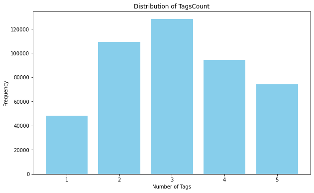

```python
# Group posts by "TagsCount" (number of tags assigned per post) and count occurrences
df_tags_distribution = df_tags_analysis.groupBy("TagsCount") \
                                       .agg(count("*").alias("TagsFrequency")) \
                                       .orderBy(col("TagsCount"))

#Convert the Spark DataFrame to a Python list for plotting
try:
    df_tags_distribution = df_tags_distribution.collect()  # Convert DataFrame to a list of Row objects
except Exception as e:
    print(f"Error while collecting tag distribution data: {e}")
    df_tags_distribution = []

# Extract x (TagsCount) and y (Frequency) values for plotting
x_TagsCount = [row['TagsCount'] for row in df_tags_distribution]
y_TagsFrequency = [row['TagsFrequency'] for row in df_tags_distribution]

# Plot the distribution using matplotlib
plt.figure(figsize=(10, 6))
plt.bar(x_TagsCount, y_TagsFrequency, color='skyblue')
plt.xlabel("Number of Tags")
plt.ylabel("Frequency")
plt.title("Distribution of TagsCount")
plt.xticks(x_TagsCount)
plt.show()
```

The graph shows that most posts have between 2 and 3 tags, with 3 tags being the most common. Posts with only 1 tag are relatively rare, while posts with 4 or 5 tags appear less frequently but are still common. This distribution suggests that users typically assign multiple tags to posts, likely to increase visibility and improve categorization.

### Tags Wordcloud

This analyzes the frequency of tags in a dataset by breaking multi-tag entries into separate rows, counting occurrences, and selecting the top 200 most frequent tags. It then creates a word cloud visualization, where the size of each word represents its frequency in the dataset.

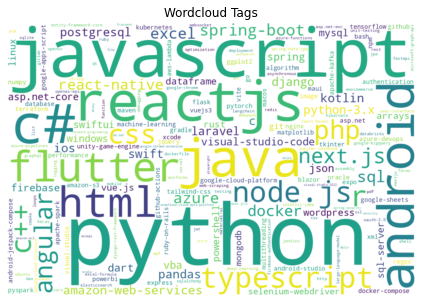

```python
# Explode array of tags into multiple rows (each containing 1 tag)
df_tags_analysis_exploded = df_tags_analysis.withColumn("TagsTokensExploded", explode(col("TagsTokens")))

# Group by the exploded tags and count how many times each tag appears
df_tags_analysis_exploded = df_tags_analysis_exploded.groupBy("TagsTokensExploded") \
                                                     .agg(count("*").alias("TagsSum"))

# Order tags by frequency (descending order)
df_tags_analysis_exploded = df_tags_analysis_exploded.orderBy(desc("TagsSum"))

# Collect the top 200 most frequent tags for visualization
try:
    df_tags_rows = df_tags_analysis_exploded.limit(200).collect()
except Exception as e:
    print(f"Error while collecting top tags: {e}")
    df_tags_rows = []

# Convert collected data into a dictionary for the word cloud
df_tags_wordfreq = {row['TagsTokensExploded']: row['TagsSum'] for row in df_tags_rows}

# Generate the word cloud from tag frequencies
wordcloud_tags = WordCloud(width=1200, height=800, background_color="white").generate_from_frequencies(df_tags_wordfreq)

# Plot the word cloud
plt.figure(figsize=(10, 5))
plt.imshow(wordcloud_tags, interpolation='bilinear')
plt.axis("off")
plt.title("Wordcloud Tags")
plt.show()
```

The word cloud highlights the most commonly used tags in the dataset. Larger words, such as "python," "javascript," and "reactjs," indicate high usage frequency, suggesting that these languages are popular discussion topics. Smaller words represent less frequently used tags but still contribute to the overall distribution of topics.

### Tags Popularity 2024 Analysis

This analyzes the usage trends of the 10 most frequently used tags by calculating their relative monthly changes in frequency from January to September 2024. It then creates a line chart where each line represents a tag, showing how its popularity fluctuates over time.

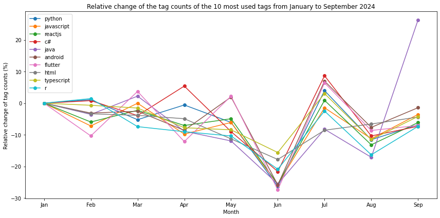

```python
from pyspark.sql.functions import col, explode, date_format, to_date, concat, lit, lag, when
from pyspark.sql.window import Window
import matplotlib.pyplot as plt

# Select relevant columns from the dataset (assumes df_posts contains "TagsTokens" and "CreationDate")
df_tags_analysis = df_posts.select("TagsTokens", "CreationDate")

# Explode the TagsTokens array so that each tag appears in its own row
df_tags_analysis = df_tags_analysis.withColumn("Tag", explode(col("TagsTokens")))

# Compute the total count of each tag and extract the top 10 most frequent tags
tag_totals = df_tags_analysis.groupBy("Tag").count()
top_tags = [row["Tag"] for row in tag_totals.orderBy(col("count").desc()).limit(10).collect()]

# Filter the dataset to only include rows with the top 10 tags
df_tags_analysis = df_tags_analysis.filter(col("Tag").isin(top_tags))

# Extract the year and month from CreationDate to group tag usage by month
df_tags_analysis = df_tags_analysis.withColumn("YearMonth", date_format(col("CreationDate"), "yyyy-MM"))

# Count occurrences of each tag per month
df_tags_analysis = df_tags_analysis.groupBy("Tag", "YearMonth").count()

# Convert YearMonth into an actual date format (yyyy-MM-01) for proper sorting
df_monthly_count = df_tags_analysis.withColumn(
    "MonthDate", to_date(concat(col("YearMonth"), lit("-01")), "yyyy-MM-dd")
)

# Define a window function to order each tag's count chronologically by month
windowSpec = Window.partitionBy("Tag").orderBy("MonthDate")

# Retrieve the previous month's count for each tag to compute relative changes
df_monthly_count = df_monthly_count.withColumn("prev_count", lag("count").over(windowSpec))

# Compute the relative change in tag count compared to the previous month
# The first month has no previous data, so we set its change to 0%
df_monthly_count = df_monthly_count.withColumn(
    "rel_change",
    when(col("prev_count").isNull(), 0)
    .otherwise((col("count") - col("prev_count")) / col("prev_count") * 100)
)

# Collect processed data for visualization
result = {}

for tag in top_tags:
    try:
        # Retrieve the data for each tag, ordered by month
        rows = df_monthly_count.filter(col("Tag") == tag).orderBy("MonthDate").select("YearMonth", "rel_change").collect()
        months = [int(row["YearMonth"][-2:]) for row in rows if row["YearMonth"]]  # Extract numerical month values
        changes = [row["rel_change"] for row in rows]
        result[tag] = (months, changes)
    except Exception as e:
        print(f"Error processing tag '{tag}': {e}")

# Plot the relative changes in tag usage over time
plt.figure(figsize=(12, 6))

for tag, (months, changes) in result.items():
    plt.plot(months, changes, marker="o", label=tag)

plt.xlabel("Month")
plt.ylabel("Relative change of tag counts (%)")
plt.title("Relative change of the tag counts of the 10 most used tags from January to September 2024")
plt.legend()

# Adjust x-axis labels to show months
plt.xticks(range(1, 10), ["Jan", "Feb", "Mar", "Apr", "May", "Jun", "Jul", "Aug", "Sep"])
plt.tight_layout()
plt.show()
```

## Creation Date

### Collect Dataset

```python
# Extract relevant columns for this analysis from df_posts
df_time_analysis = df_posts.select("ViewCount", "CreationDate", "HourOfDay", "Weekday", "Month", "PostAge")
```

### HourOfDay Analysis

This analyzes the distribution of posts by hour of the day, counting how many posts were created during each hour. It then visualizes the frequency of posts per hour using a bar chart, making it easy to identify peak activity times.

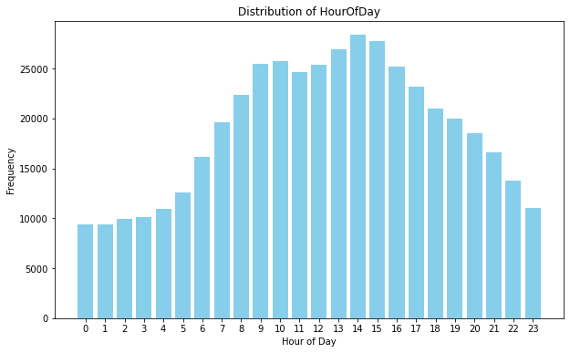

```python
from pyspark.sql.functions import col, count
import matplotlib.pyplot as plt

# Aggregate post counts per hour of the day
df_hourofday_distribution = df_time_analysis.groupBy("HourOfDay") \
                                            .agg(count("*").alias("HourOfDayFrequency")) \
                                            .orderBy(col("HourOfDay"))

# Collect the aggregated data for plotting
try:
    df_hourofday_distribution = df_hourofday_distribution.collect()
except Exception as e:
    print(f"Error while collecting HourOfDay distribution data: {e}")
    df_hourofday_distribution = []

# Extract x (Hour of the Day) and y (Frequency) values
x_HourOfDay = [row['HourOfDay'] for row in df_hourofday_distribution]
y_HourOfDayFrequency = [row['HourOfDayFrequency'] for row in df_hourofday_distribution]

# Plot the distribution using matplotlib
plt.figure(figsize=(10, 6))
plt.bar(x_HourOfDay, y_HourOfDayFrequency, color='skyblue')
plt.xlabel("Hour of Day")
plt.ylabel("Frequency")
plt.title("Distribution of HourOfDay")
plt.xticks(x_HourOfDay)
plt.show()
```

The graph shows that posting activity gradually increases in the morning, peaking between 13:00 and 15:00 (1-3 PM). After this peak, activity gradually declines towards the evening and night, with the lowest number of posts occurring in the late night hours (after 22:00). This suggests that users are most active in the early afternoon, possibly during work or study.

### CreationDate Heatmap

This code analyzes the number of questions posted on different weekdays across months by extracting weekday and month information from the post timestamps. It then creates a heatmap where color intensity represents the frequency of questions, helping visualize posting trends over time.

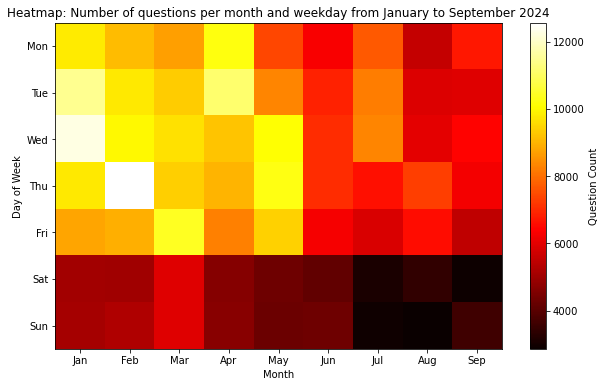

```python
import matplotlib.pyplot as plt
from pyspark.sql.functions import col, count, month, dayofweek

# Extract the month (1-12) and day of the week (Sunday=1, Monday=2, ..., Saturday=7) from the CreationDate
df_post_heatmap = df_time_analysis.withColumn("month_num", month(col("CreationDate")))

# Convert Sunday (1) to Monday (1), Monday (2) to Tuesday (2), etc., for better visualization
df_post_heatmap = df_post_heatmap.withColumn("weekday_num", ((dayofweek(col("CreationDate")) + 5) % 7) + 1)

# Count the number of questions for each combination of month and weekday
df_post_heatmap_count = df_post_heatmap.groupBy("month_num", "weekday_num").agg(count("*").alias("question_count"))

# Create a matrix where rows represent weekdays and columns represent months (pivot table)
df_heatmap = df_post_heatmap_count.groupBy("weekday_num") \
                                  .pivot("month_num", list(range(1, 13))) \
                                  .sum("question_count") \
                                  .orderBy("weekday_num")

# Collect data to construct a array for visualization
try:
    heatmap_data = df_heatmap.orderBy("weekday_num").collect()
except Exception as e:
    print(f"Error while collecting heatmap data: {e}")
    heatmap_data = []

# Define the months to be included in the heatmap (January to September)
months = list(range(1, 10))  # Skipping October to December if no data is available

# Initialize a 7 (weekdays) x 9 (months) matrix filled with zeros
heatmap_matrix = [[0 for _ in months] for _ in range(7)]

# Populate the matrix with the count of questions for each weekday and month
for row in heatmap_data:
    weekday_idx = row["weekday_num"]
    if weekday_idx is None:
        continue  # Skip invalid rows

    weekday_idx = int(weekday_idx) - 1  # Convert to 0-based index
    row_dict = row.asDict()
    for m in months:
        count_val = row_dict.get(str(m), 0)  # Get count or default to 0
        heatmap_matrix[weekday_idx][m - 1] = count_val

# Define weekday labels (Monday to Sunday)
weekdays = ["Mon", "Tue", "Wed", "Thu", "Fri", "Sat", "Sun"]

# Generate the heatmap visualization
plt.figure(figsize=(10, 6))
plt.imshow(heatmap_matrix, cmap="hot", aspect="auto")
plt.colorbar(label="Question Count")

# Label the axes with month names and weekdays
plt.xticks(list(range(len(months))), ["Jan", "Feb", "Mar", "Apr", "May", "Jun", "Jul", "Aug", "Sep"])
plt.yticks(list(range(len(weekdays))), weekdays)

plt.xlabel("Month")
plt.ylabel("Day of Week")
plt.title("Heatmap: Number of questions per month and weekday from January to September 2024")
plt.show()
```

## Knowledge Gap

### What is a knowledge gap?

The KnowledgeGap metric is a way to measure how much a programming language struggles with unanswered questions. Instead of just counting the total number of unanswered questions, which can be misleading since languages with more total questions naturally have more unanswered ones, this method looks at two important factors:

#### Unanswered Ratio

This represents the fraction of unanswered questions relative to the total number of questions in that language. It is calculated as:

$$ UnansweredRatio = \frac{\text{TotalQuestions} - \text{AnsweredQuestions}}{\text{TotalQuestions}} $$

A higher value means a larger percentage of questions in that language are going unanswered.

#### Unanswered View Impact

This measures how often unanswered questions are viewed compared to other languages. If a question is seen by many people but still remains unanswered, it suggests a bigger knowledge gap. This is calculated as:

$$ UnansweredViewImpact = \frac{\text{AvgUnansweredViews}}{\max(\text{AvgUnansweredViews})} $$

The highest average view count among all languages is used as the reference point to scale the values between 0 and 1.

#### Final Knowledge Gap Calculation

Finally, the KnowledgeGap score is computed by multiplying these two factors:

$$ KnowledgeGap = UnansweredRatio \times UnansweredViewImpact $$

This method makes sure that languages with a high proportion of unanswered questions AND high visibility of those questions are recognized as having a greater knowledge gap. It provides a fairer comparison by not just looking at raw numbers but also considering how much people struggle to find answers despite high interest.

### Preprocessing

This section extracts relevant posts that contain programming-related tags, ensuring that only frequently used languages are analyzed. The dataset is sampled (10%) for efficiency and exploded to analyze each tag separately.

```python
from pyspark.sql.functions import col, split, regexp_replace, count, when, avg, max, sum, lower, first, explode
from pyspark.sql.window import Window
import matplotlib.pyplot as plt

# Define the top programming languages for analysis
top_languages = ["python", "java", "c#", "javascript", "c++", "php", "go", "ruby"]

# Select relevant columns from the dataset
df_knowledge_gap = df_posts.select("Id", "ViewCount", "AnswerCount", "TagsTokens")

# Filter out posts where ViewCount is zero (as they provide no engagement data)
df_knowledge_gap = df_knowledge_gap.filter(col("ViewCount") > 0)

# Take a 10% random sample for processing efficiency
df_knowledge_gap = df_knowledge_gap.sample(fraction=0.1, seed=1234)

# Explode the TagsTokens column so that each tag appears in its own row
df_knowledge_gap = df_knowledge_gap.withColumn("TagsTokensExploded", explode(col("TagsTokens")))

# Filter the dataset to only include posts related to the predefined top programming languages
df_knowledge_gap = df_knowledge_gap.filter(
    lower(col("TagsTokensExploded")).isin([lng.lower() for lng in top_languages])
)
```

### Aggregating Data

This section aggregates data per language, calculating key statistics like total questions, answered questions, and unanswered question ratios. It also computes the average number of views for unanswered questions, which indicates how often unanswered questions are still viewed.

```python
# Group by post ID and select the first encountered programming language as the primary language for that post
df_knowledge_gap = df_knowledge_gap.groupBy("Id") \
    .agg(
        first("TagsTokensExploded").alias("PrimaryLanguage"),
        max("ViewCount").alias("ViewCount"),
        max("AnswerCount").alias("AnswerCount")
    )

# Drop the ID column as it's no longer needed
df_knowledge_gap = df_knowledge_gap.drop("Id")

# Aggregate metrics for each programming language
df_agg = df_knowledge_gap.groupBy("PrimaryLanguage").agg(
    count("*").alias("TotalQuestions"),  # Total number of questions per language
    count(when(col("AnswerCount") > 0, 1)).alias("AnsweredQuestions")  # Count only answered questions
)

# Calculate the ratio of unanswered questions per language
df_agg = df_agg.withColumn("UnansweredRatio", (col("TotalQuestions") - col("AnsweredQuestions")) / col("TotalQuestions"))

# Calculate the average number of views for unanswered questions per language
df_unanswered_views = df_knowledge_gap.filter(col("AnswerCount") == 0).groupBy("PrimaryLanguage").agg(
    avg("ViewCount").alias("AvgUnansweredViews")
)

# Merge unanswered view count data
df_agg = df_agg.join(df_unanswered_views, "PrimaryLanguage", "left")
```

### Calculating the Knowledge Gap Score

This section calculates the "Knowledge Gap Score", which is the product of the unanswered ratio and the relative impact of unanswered views. The resulting score helps identify languages where questions often go unanswered but are still frequently viewed, indicating a gap in available expertise.

```python
# Define a window function to allow scaling calculations
window_spec = Window.rowsBetween(Window.unboundedPreceding, Window.unboundedFollowing)

# Normalize unanswered views impact by dividing by the maximum value
df_agg = df_agg.withColumn(
    "UnansweredViewImpact",
    when(col("AvgUnansweredViews").isNotNull() & (max("AvgUnansweredViews").over(window_spec) > 0),
         col("AvgUnansweredViews") / max("AvgUnansweredViews").over(window_spec)
    ).otherwise(0)  # If denominator is 0, set impact to 0
)

# Compute the final Knowledge Gap Score by multiplying UnansweredRatio with UnansweredViewImpact
df_agg = df_agg.withColumn("KnowledgeGap", col("UnansweredRatio") * col("UnansweredViewImpact"))

# Sort results by Knowledge Gap Score in descending order
df_agg = df_agg.orderBy(col("KnowledgeGap").desc())

# Display the final dataset
df_agg.select("PrimaryLanguage", "TotalQuestions", "AnsweredQuestions", "UnansweredRatio", "AvgUnansweredViews", "UnansweredViewImpact", "KnowledgeGap").show(50, truncate=10)
```

```
+---------------+--------------+-----------------+---------------+------------------+--------------------+------------+
|PrimaryLanguage|TotalQuestions|AnsweredQuestions|UnansweredRatio|AvgUnansweredViews|UnansweredViewImpact|KnowledgeGap|
+---------------+--------------+-----------------+---------------+------------------+--------------------+------------+
|             go|           244|              132|     0.45901...|        101.098...|                 1.0|  0.45901...|
|            php|           959|              493|     0.48592...|        75.3261...|          0.74507...|  0.36205...|
|           java|          1854|             1040|     0.43905...|        81.0221...|          0.80141...|  0.35186...|
|     javascript|          3309|             1850|     0.44091...|        77.6086...|          0.76765...|  0.33847...|
|         python|          5642|             3275|     0.41953...|        74.9678...|          0.74153...|  0.31109...|
|             c#|          1978|             1202|     0.39231...|        73.4445...|          0.72646...|  0.28500...|
|            c++|          1115|              737|     0.33901...|        81.2195...|          0.80337...|  0.27235...|
|           ruby|           114|               84|     0.26315...|        99.7333...|          0.98649...|  0.25960...|
+---------------+--------------+-----------------+---------------+------------------+--------------------+------------+
```

### Visualizing the Knowledge Gap

This section creates a bar chart where each programming language is plotted along with its Knowledge Gap Score. The higher the score, the larger the gap, indicating languages with a high percentage of unanswered but frequently viewed questions.

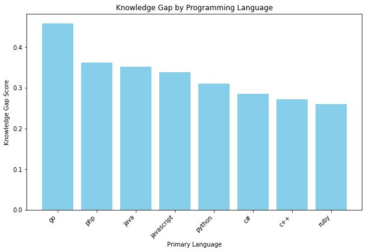

```python
# Collect data for visualization
data = df_agg.select("PrimaryLanguage", "KnowledgeGap").collect()
languages = [row["PrimaryLanguage"] for row in data]
knowledge_gaps = [row["KnowledgeGap"] for row in data]

# Create a vertical bar chart
plt.figure(figsize=(10, 6))
plt.bar(languages, knowledge_gaps, color="skyblue")
plt.xlabel("Primary Language")
plt.ylabel("Knowledge Gap Score")
plt.title("Knowledge Gap by Programming Language")

# Rotate x-axis labels for readability
plt.xticks(rotation=45, ha="right")

# Show the plot
plt.show()
```

### Interpretation

The graph shows that Php and Go have the highest Knowledge Gap Scores, suggesting that a significant number of questions remain unanswered, yet they attract many views. This could indicate that there is a shortage of experts answering Php and Go questions. Conversely, C++ and ruby have the lowest scores, suggesting that their unanswered questions attract less attention or they have a stronger answering community.

# Task 1: Primary Language Detection

### Task Overview

This section focuses on predicting the primary programming language of a given text-based question. The task is formulated as a multiclass classification problem, where a machine learning model assigns each question to one of several possible programming languages based on its textual content.

Question: What programming language does a question belong to?

**Dataset and Features**  
The dataset consists of tokenized text and tags extracted from programming-related questions. The following columns are used for training:

- TextTokens – Tokenized representation of the question’s text
- TagTokens – Tokenized representation of the associated tags

**Machine Learning Models**  
Three different classification models are trained and evaluated:

- Logistic Regression
- Naive Bayes
- Random Forest Classifier

For each model, the process consists of three key steps:

1. Model Building – Constructing the model, defining the pipeline, and setting up cross-validation
2. Training and Checkpointing – Either loading a previously trained model or training a new model and saving it
3. Evaluation – Computing classification metrics to compare model performance

**Pipeline Construction**  
To transform raw text into a format suitable for classification, a five-step preprocessing pipeline is implemented:

1. Tokenization (Preprocessed before pipeline)
2. Count Vectorization – Converts text into raw term frequency vectors
3. IDF Transformation – Adjusts term frequencies based on their importance across documents
4. String Indexing – Converts categorical language labels into numerical indices
5. Model Addition – Attaches the classification model at the final stage

**Cross-Validation and Hyperparameter Tuning**  
To improve model performance, cross-validation is applied with a predefined hyperparameter grid. The tuning process focuses on maximizing accuracy, adjusting parameters such as:

- Vocabulary size for CountVectorizer
- Regularization parameter for Logistic Regression
- Smoothing parameter for Naive Bayes
- Tree count and depth for Random Forest

**Model Selection**  
At the end of the process, the best-performing model is selected based on evaluation metrics such as accuracy, precision, recall and F1-score. The results provide insights into how well each model differentiates between programming languages based on textual patterns.

## Preparation

### Import Libraries

#### Machine Learning Libraries

```python
# Pipeline Libraries:
# 1. Pipeline = Chains multiple data transformation and modeling stages into a single workflow
# 2. CountVectorizer = Converts tokenized text into a sparse vector of raw term frequencies
# 3. IDF = Applies Inverse Document Frequency (IDF) weighting to emphasize informative words
# 4. StringIndexer = Converts categorical string labels into numerical indices for machine learning
# 5. IndexToString = Converts indexed numerical predictions back into their original string labels
from pyspark.ml import Pipeline
from pyspark.ml.feature import CountVectorizer, IDF, StringIndexer, IndexToString

# Cross Validation Libraries:
# 1. ParamGridBuilder = Defines hyperparameter combinations for model tuning during cross-validation
# 2. CrossValidator = Performs k-fold cross-validation to find the best model based on evaluation metrics
# 3. CrossValidatorModel = Stores the best model obtained from cross-validation for later use
from pyspark.ml.tuning import ParamGridBuilder, CrossValidator, CrossValidatorModel

# Machine Learning Libraries
# 1. LogisticRegression = A linear classification model that predicts probabilities using a logistic function
# 2. NaiveBayes = A probabilistic classifier based on Bayes' theorem, effective for text classification
# 3. RandomForestClassifier = An ensemble learning method that builds multiple decision trees for classification
from pyspark.ml.classification import LogisticRegression, NaiveBayes, RandomForestClassifier

# Evaluation Libraries:
# 1. MulticlassClassificationEvaluator = Computes evaluation metrics such as accuracy, precision, recall, and F1 score for multiclass classification tasks
from pyspark.ml.evaluation import MulticlassClassificationEvaluator
```

#### Other Libraries

```python
from pyspark.sql import Row
from pyspark.sql.functions import lower, first, col

# Library operating system interactions (used for storing and retrieving models)
import os

# Library for creating visualizations and plots
import matplotlib.pyplot as plt

# Library for numerical computations and array operations
import numpy as np
```